# BSB Oceanography

Ricky Tabandera

6/8/2022

## Shelf water volume

Shelf water volume which is a measure of the volume of water bounded inshore of a hydrodynamic feature called the shelf-slope front. In this analysis the shelf water is defined as all water having salinity <34. It is hypothesized that fish are migrating from the self edge and using the shelf slope font as a way-point. The position of this front will vary inter-annually with the higher values indicating the front being pushed further towards the shelf break. As this font moves closer or further from the coast, the available susceptible habitat can expand or contract as black sea bass are known to concentrate slope ward of the front. Miller et al. 2016 Identified a negative impact on catches of both juveniles and adult black sea bass when shelf water volume exceeded 4000 km^3

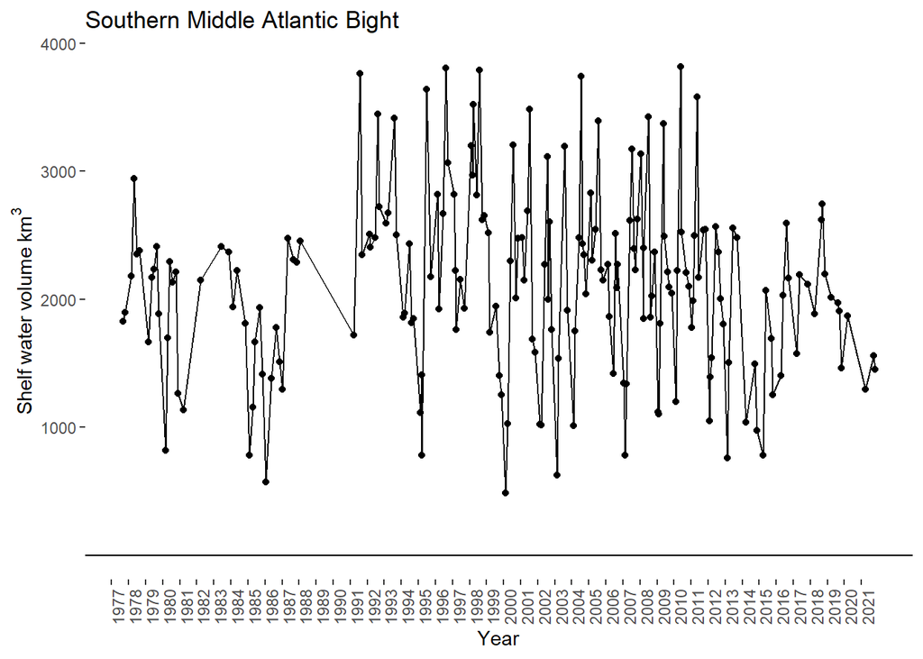

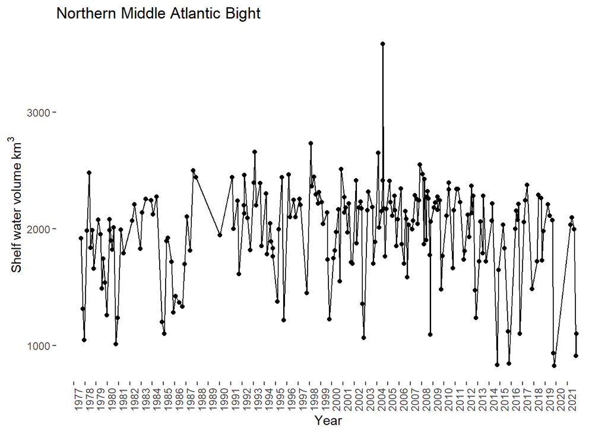

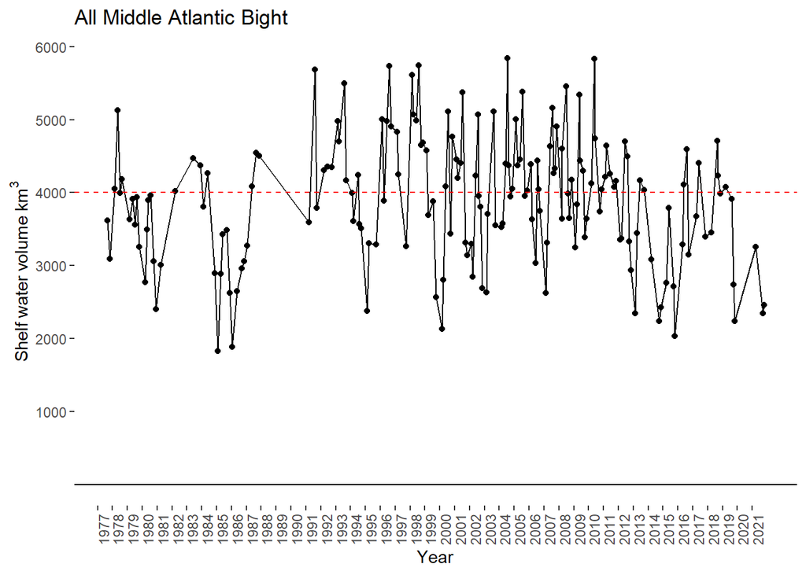

### Shelf water volume anomaly

The anomaly is the excess volume above the seasonal and regional mean for each period.

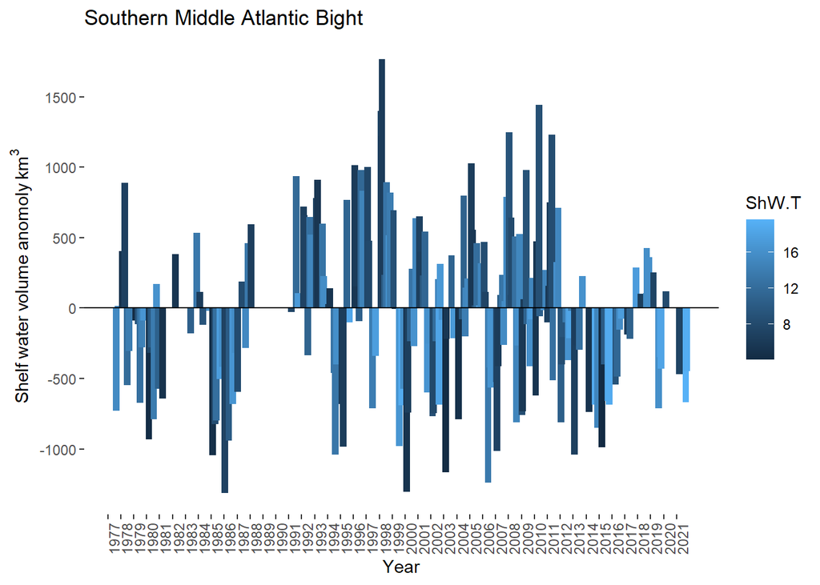

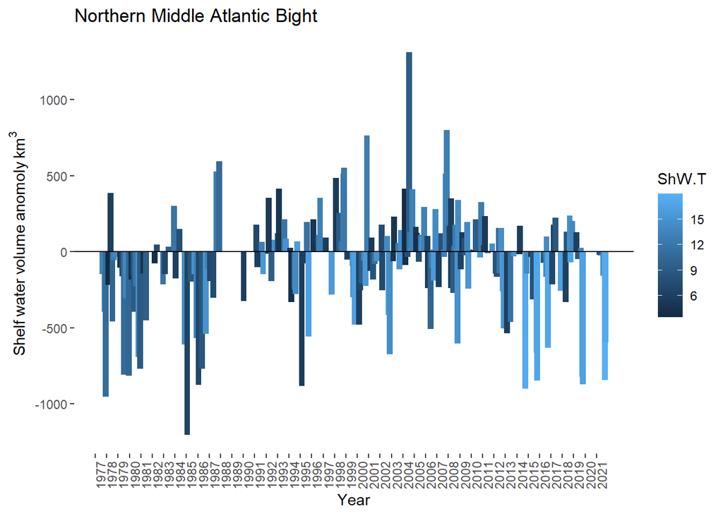

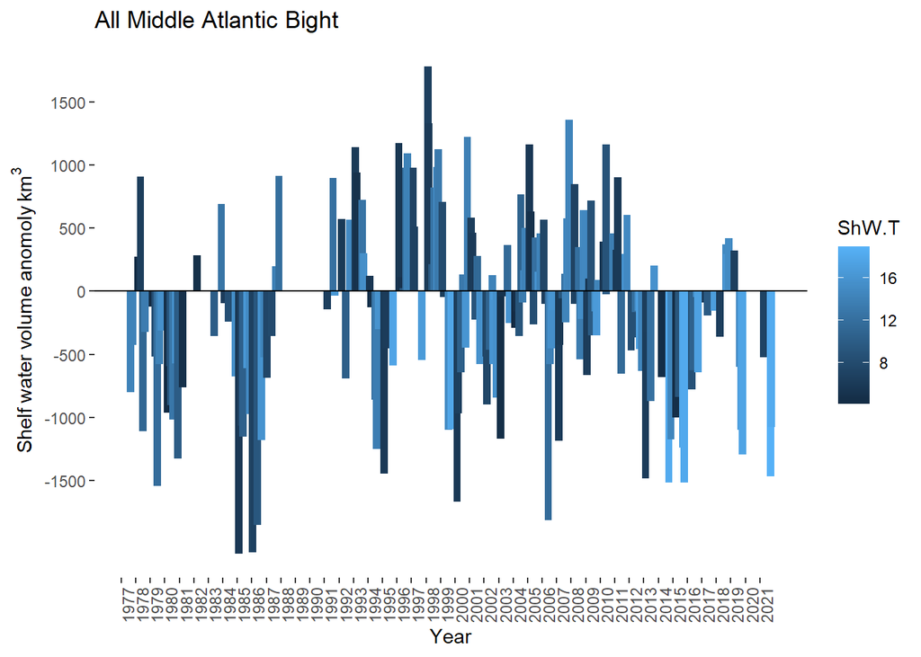

## winter shelf water volume and anomaly

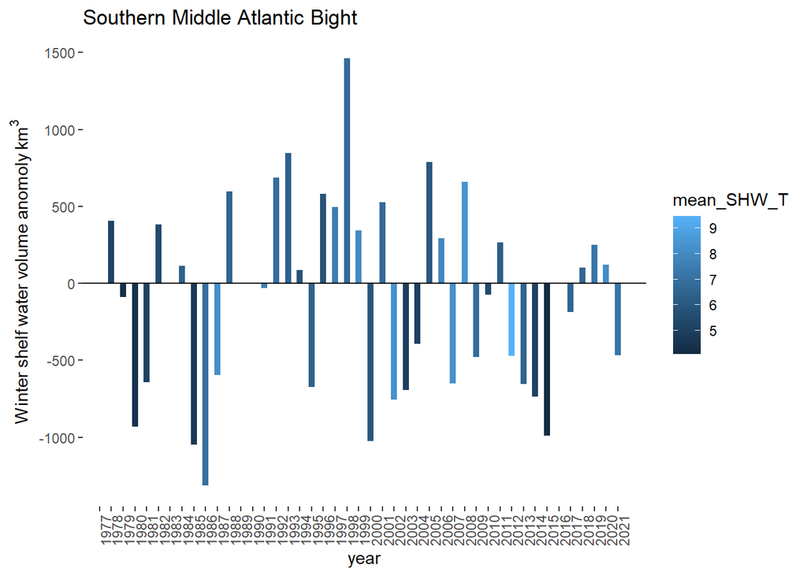

[figure not shown]

[figure not shown]

## Shelf water volume fall

To replicate Millter et al. 2016 methods the previous fall shelf water volume was used in the GAM.

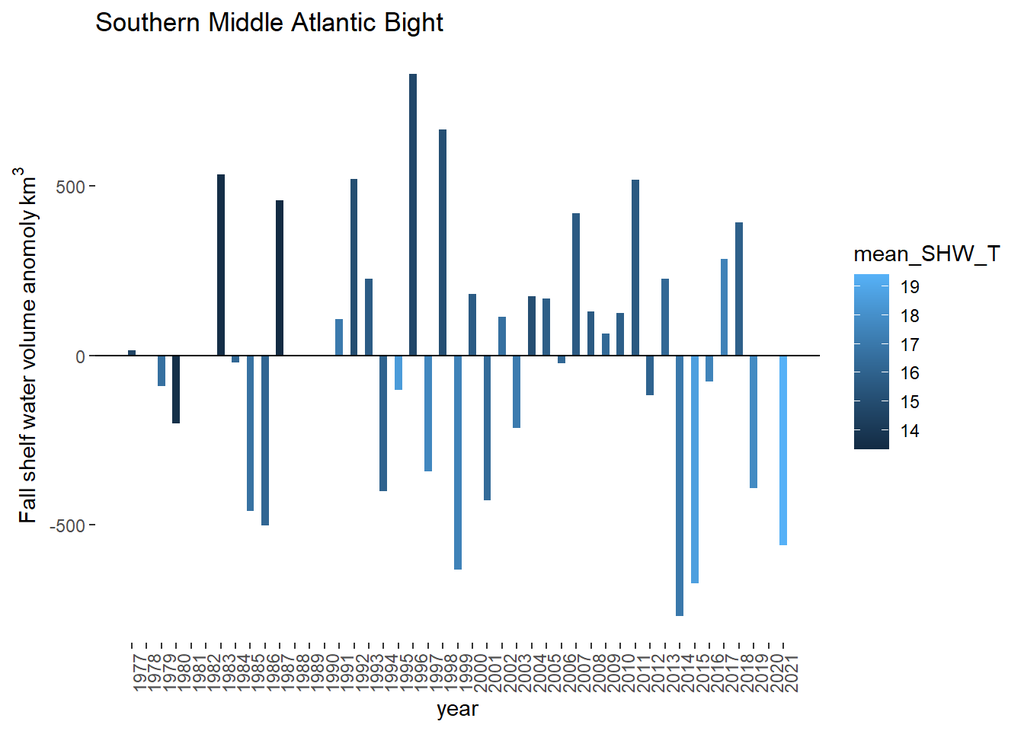

[figure not shown]

[figure not shown]

All available CTD data within 10m of the bottom between the northern and southern MAB region and as a whole. Regional time series were computed as follows: area-weighted regional mean values were computed for each survey in the OCDBS and a reference annual cycle was removed (fit to observations from 1981-2010) to get seasonal anomalies.

note: winter coverage is very sparse due to the winter ECOMON surveys ending. A better approach may to be to use a two month span at the end of winter where coverage is better i.e. FEB-MAR rather than a whole winter.

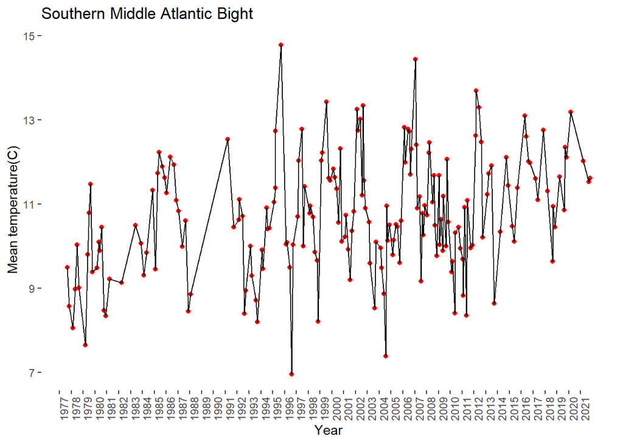

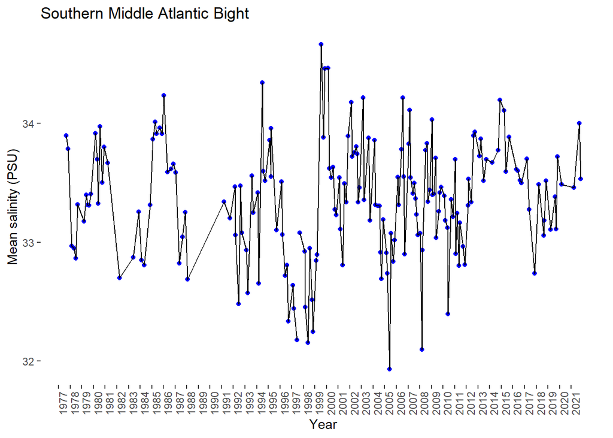

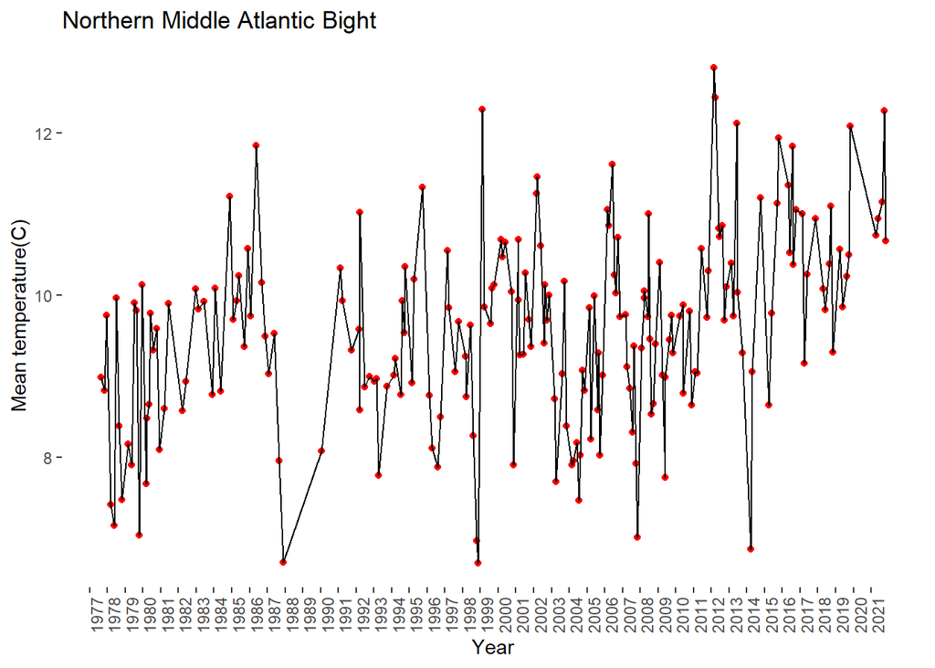

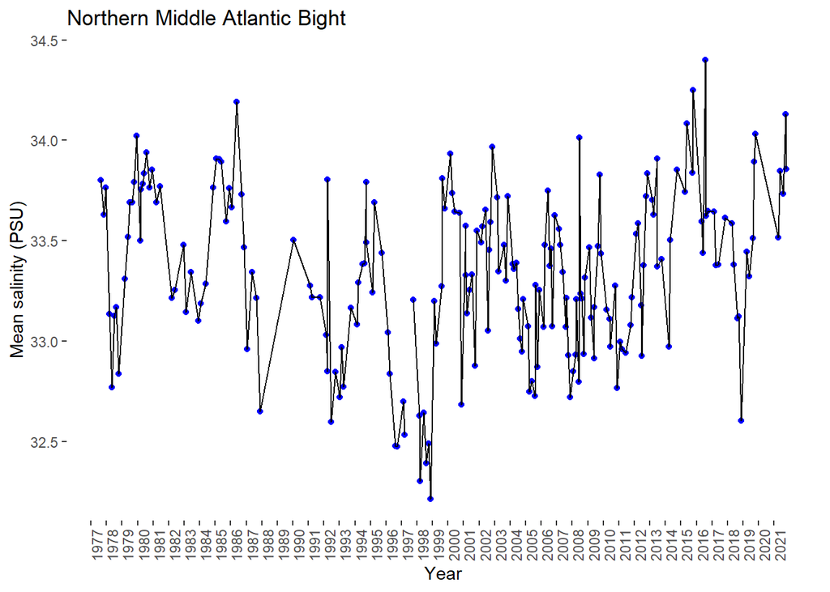

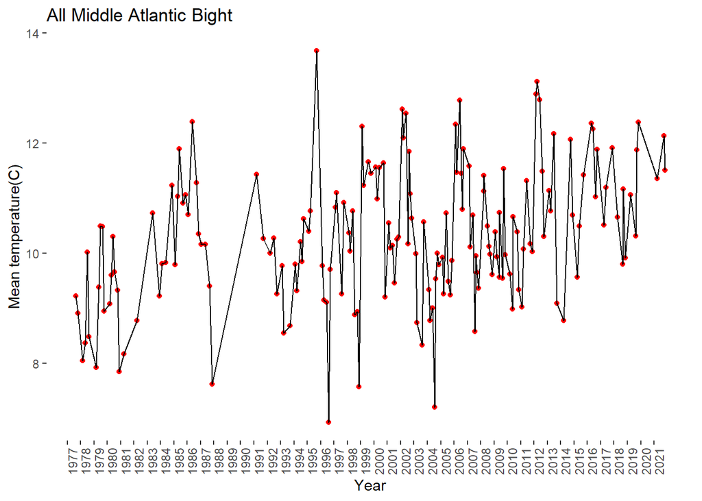

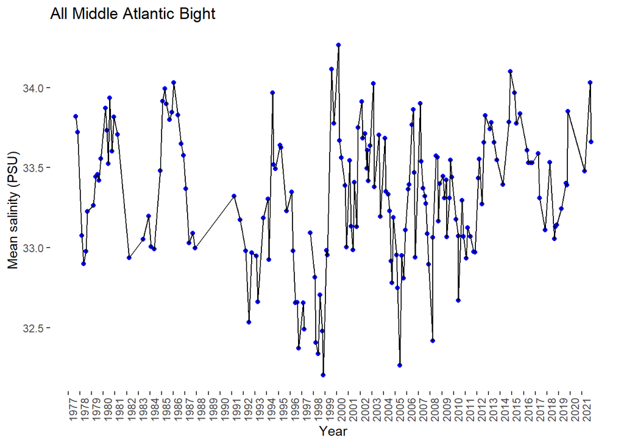

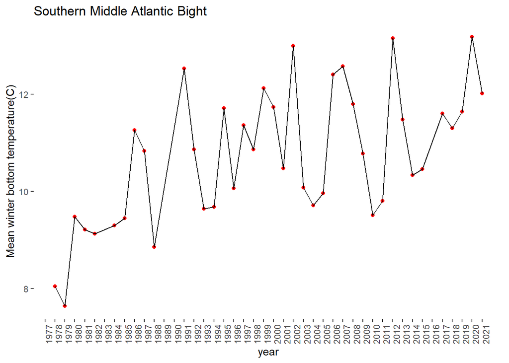

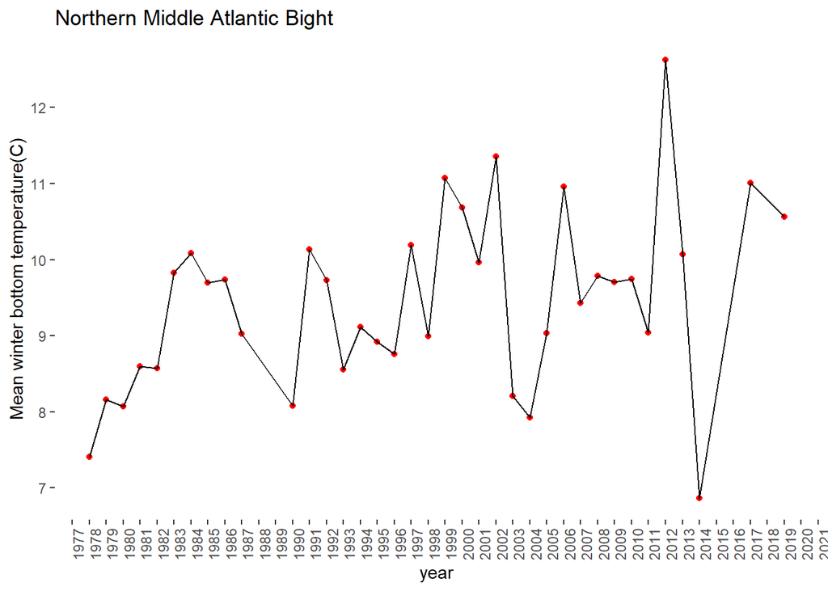

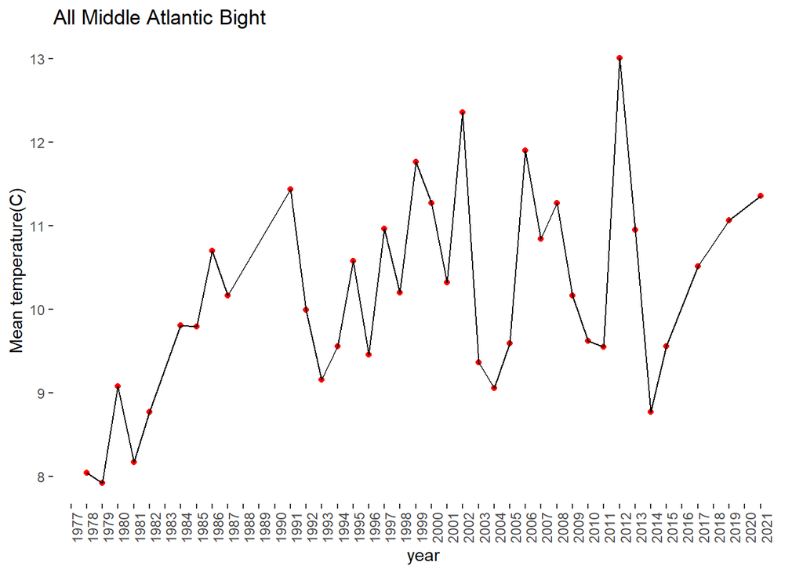

## Gulf of Maine and Georges bank bottom temperature

Placeholder with SOE information extracted from ecodata. Data occurs at annual time scale and is across the whole EPU.

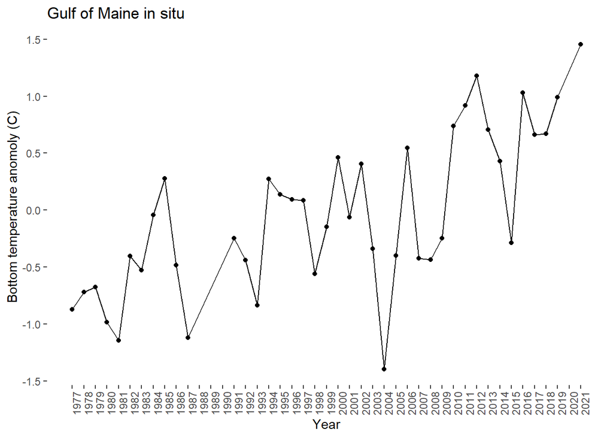

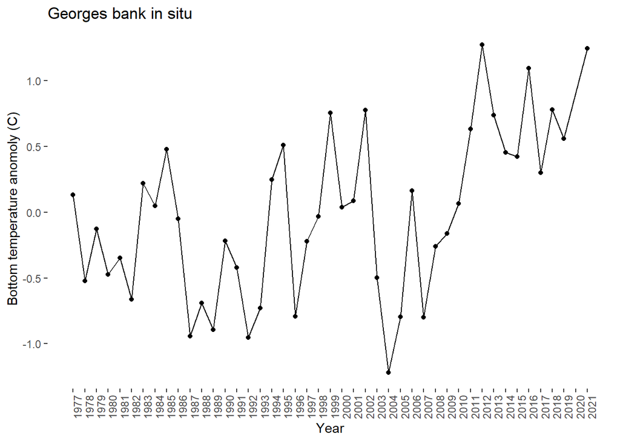

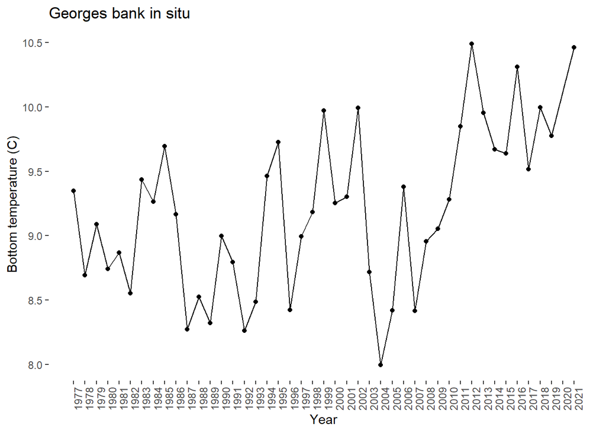

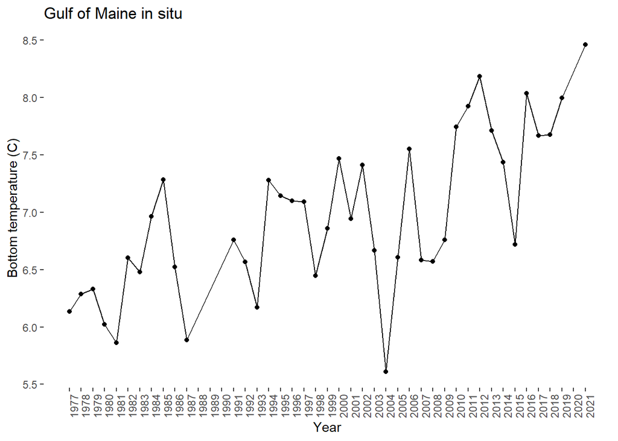